# Intro to R

Let’s add some a points “geom” layer in order to produce a scatterplot:

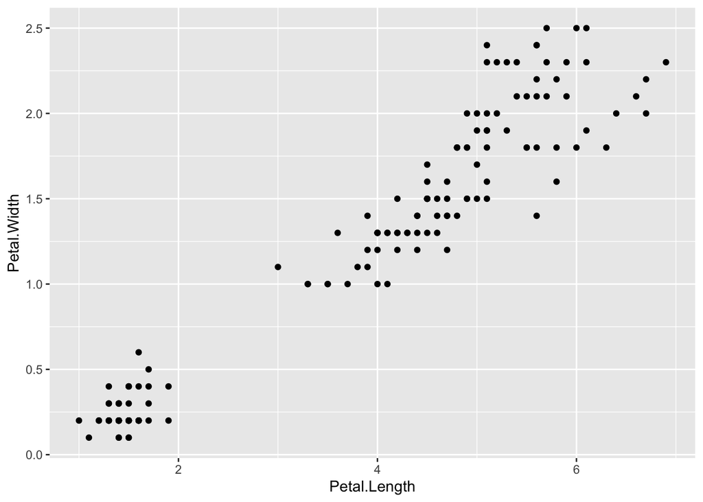

```r
ggplot(data=iris, mapping=aes(x=Petal.Length, y=Petal.Width))+
  geom_point()
```

If what we wanted was a quick and dirty figure to get a grasp of the trend in the data we can stop here. From the scatterplot that we’ve produced, we can see that petal width looks like it’s increasing with length in a linear fashion. So long as this answers the question we were asking from these data, we have a figure that is fit for purpose. However, for showing to other people we might want something a bit more developed. We could, for example, add some lines:

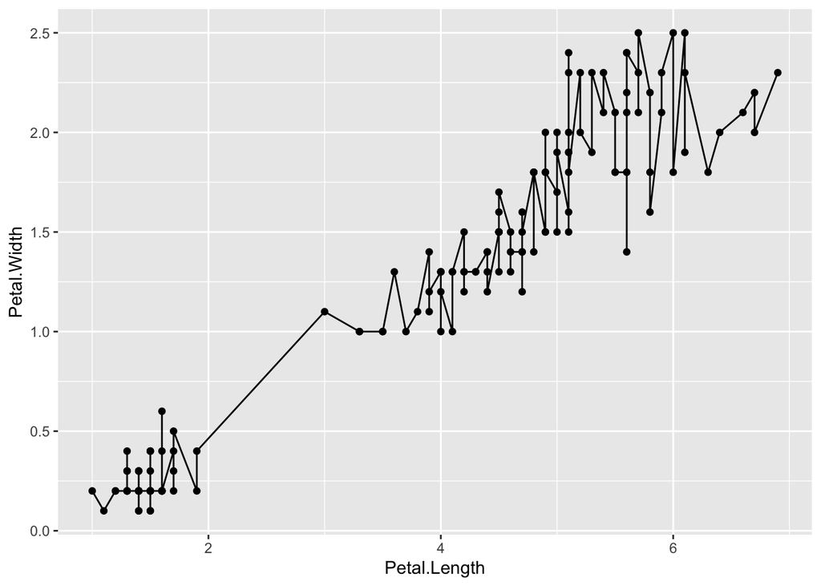

```r
ggplot(data=iris, mapping=aes(x=Petal.Length, y=Petal.Width))+
  geom_point()+
  geom_line()
```

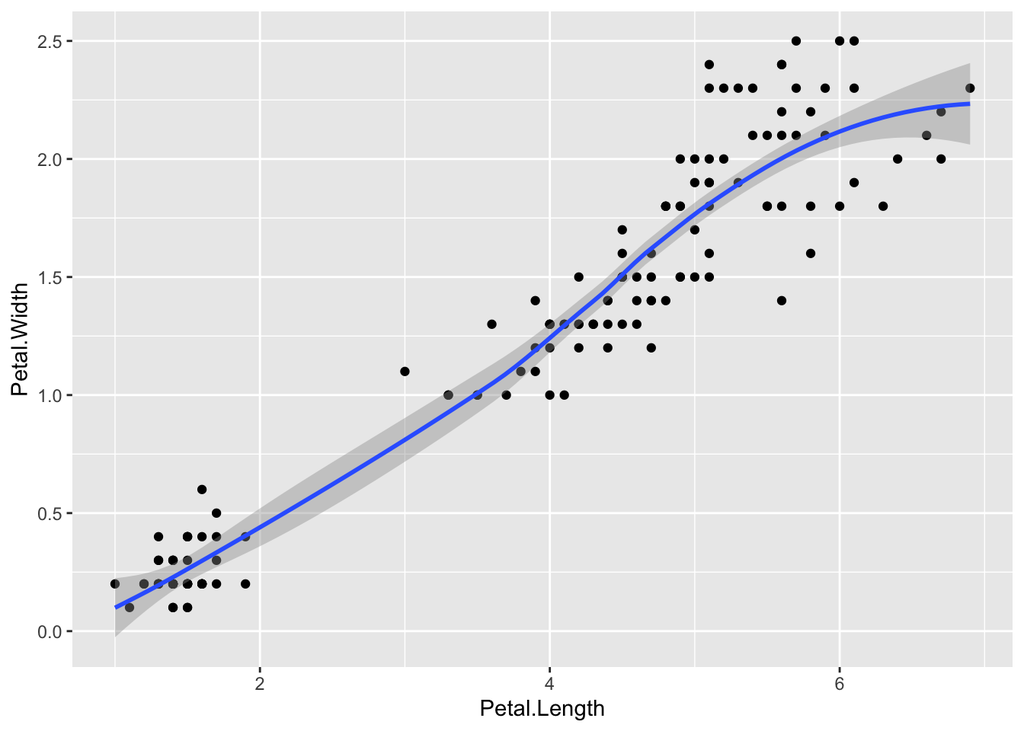

```r
ggplot(data=iris, mapping=aes(x=Petal.Length, y=Petal.Width))+
  geom_point()+
  geom_smooth()
```

There are lots of kinds of lines or trends we can use to display the data. The way our line above was drawn was by using a method called “LOESS” (locally estimated scatterplot smoothing) which gives something very close to a moving average; useful in some cases, less so in others. ggplot2 will use LOESS as default when you have < 1000 observations (something you can check in the function documentation, or using the help function), but we can manually specify the method. Instead of a wiggly line, we want a nice simple ‘line of best fit’ to be drawn using a method called “lm” (short for linear model). Try looking at the help file, using ?geom_smooth, to see what other options are available for the method = argument. While we’re at it, let’s get rid of the confidence interval ribbon around the line. We can do this at the same time as changing the method by setting the se = argument (short for standard error) to FALSE.

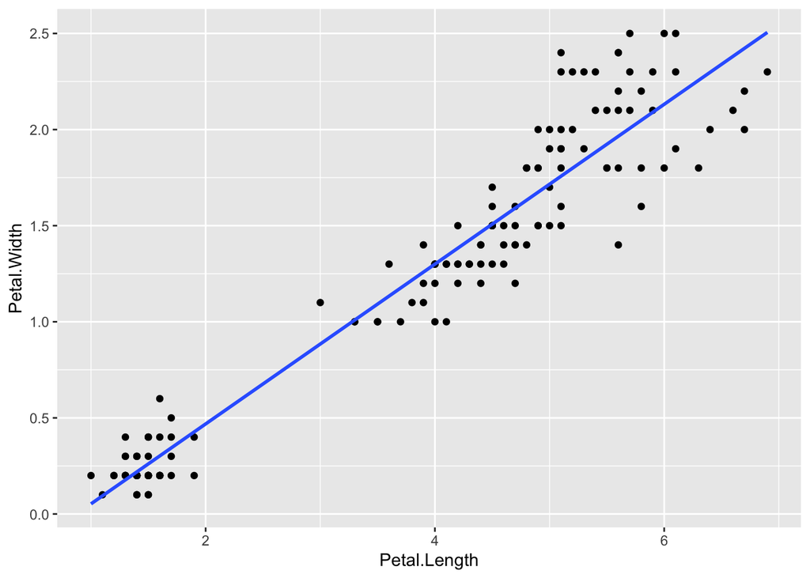

```r
ggplot(data=iris, mapping=aes(x=Petal.Length, y=Petal.Width))+
  geom_point()+
  geom_smooth(method="lm", se=FALSE)
```

The amazing thing about ggplot is you can rapidly, easily modify graphs to map different elements of your dataset to different aesthetics. Or, in other words, you can tell it to display different dimensions using different methods of visualization. Let’s say we want to know which species are which in the graph above. We can tell ggplot to map species to something we can see, like a color or shape.

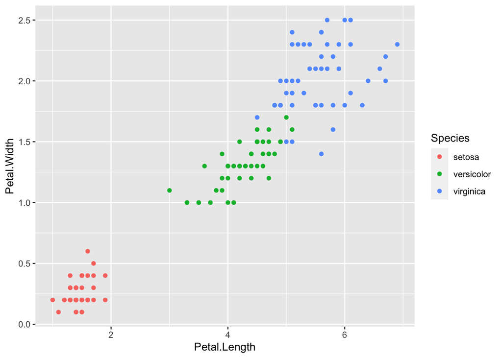

```r
#species mapped to color
ggplot(data=iris, mapping=aes(x=Petal.Length, y=Petal.Width,
                              color=Species))+
  geom_point()
```

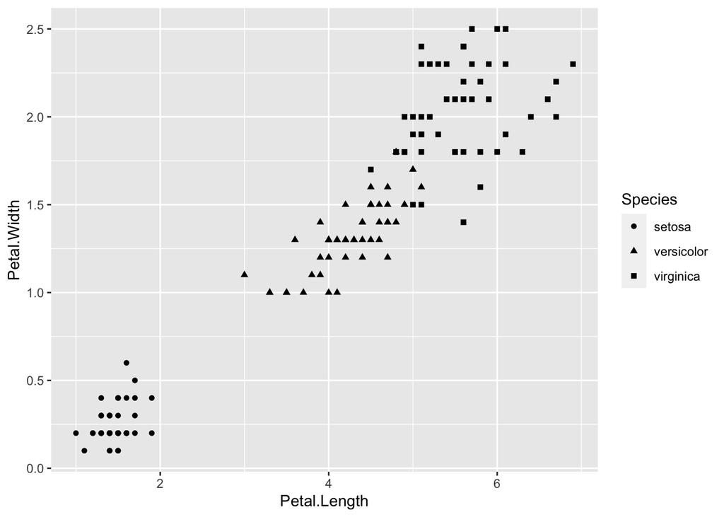

```r
#species mapped to shape. note you do not need to include "mapping="; ggplot understands this by default
ggplot(data=iris, aes(x=Petal.Length, y=Petal.Width,
                              shape=Species))+
  geom_point()
```

Or, we can tell it that species should actually be displayed on the X axis instead of Petal Length:

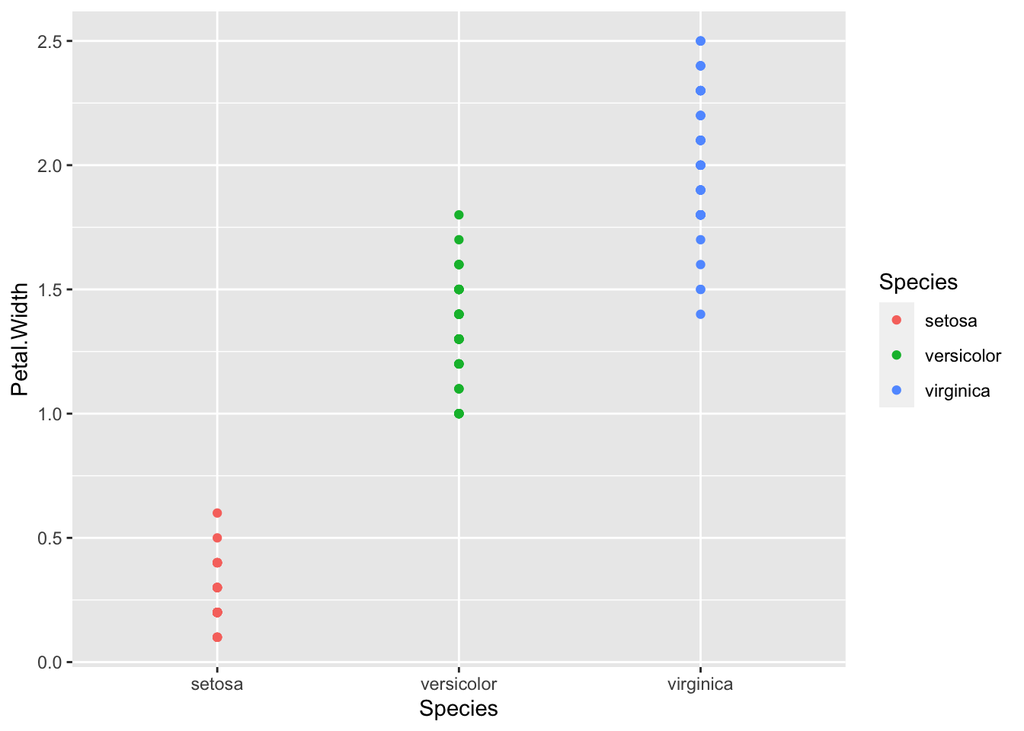

```r
#species mapped to color
ggplot(data=iris, aes(x=Species, y=Petal.Width,
                              color=Species))+
  geom_point()
```

Maybe we want a scatterplot, but a different trendline for each species. No problem.

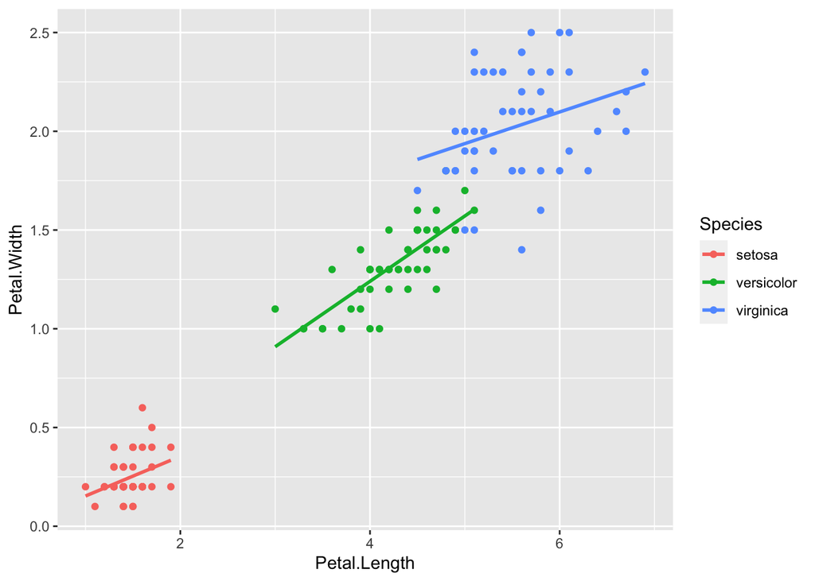

```r
ggplot(data=iris, aes(x=Petal.Length, y=Petal.Width, color=Species))+
  geom_point()+
  geom_smooth(method="lm", se=FALSE)
```

We can also tell ggplot to apply certain aesthetic mappings only to certain geoms. So, let’s say we want color to apply to the lines, but not to the points. We’ll take the color mapping out of the initial ggplot() function and add it to the geom_smooth() function.

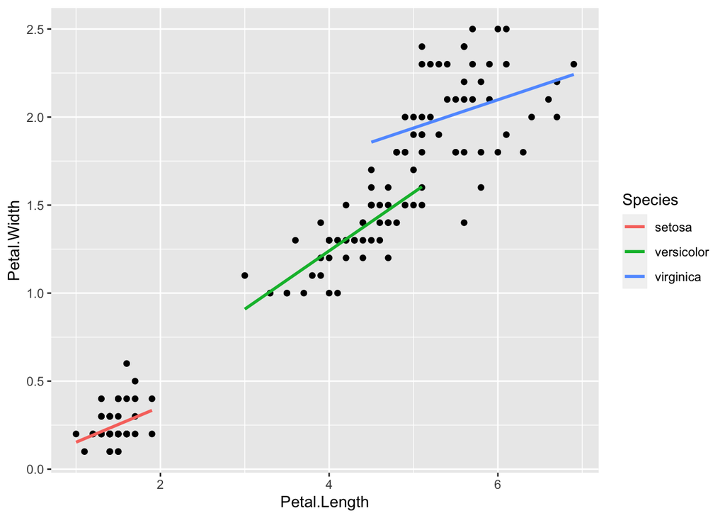

```r
ggplot(data=iris, aes(x=Petal.Length, y=Petal.Width))+
  geom_point()+
  geom_smooth(aes(color=Species), method="lm", se=FALSE)
```

What about making separate plots for each species? We can use “facets”, which display the different “faces” of the data.

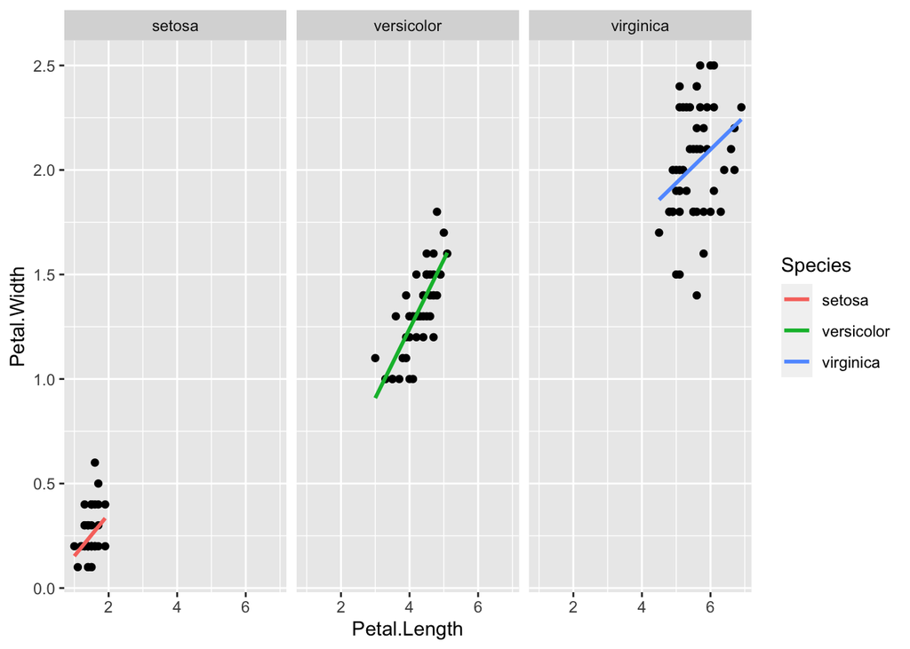

```r
ggplot(data=iris, aes(x=Petal.Length, y=Petal.Width))+
  geom_point()+
  geom_smooth(aes(color=Species), method="lm", se=FALSE)+
  facet_wrap(~Species)
```

What if I want to see another variable, or a third dimension? No problem, map it to something else you can visualize! For example, we can vary the size of the points according to Sepal Width.

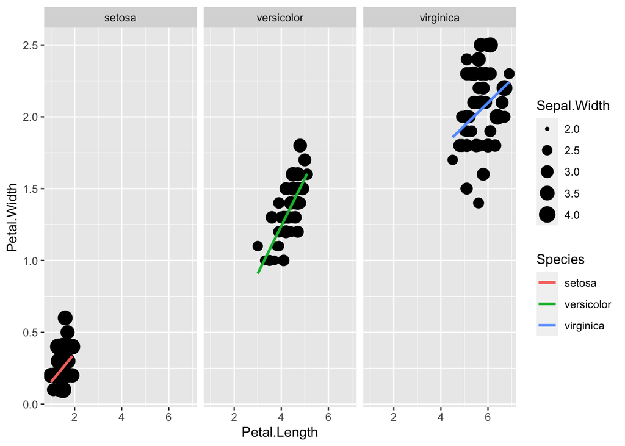

```r
ggplot(data=iris, aes(x=Petal.Length, y=Petal.Width))+
  geom_point(aes(size=Sepal.Width))+
  geom_smooth(aes(color=Species), method="lm", se=FALSE)+
  facet_wrap(~Species)
```

What about a different kind of plot entirely? We just assign whatever geoms we want, provided we have appropriate aesthetic mappings.

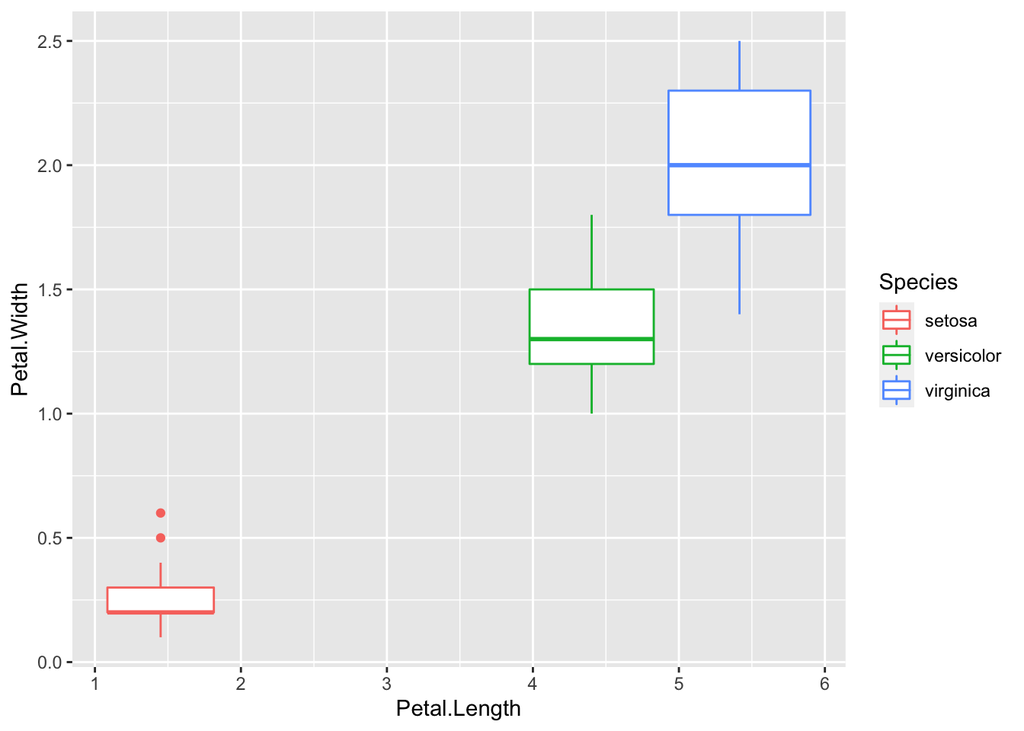

```r
#make a boxplot
ggplot(data=iris, aes(x=Petal.Length, y=Petal.Width, color=Species))+
  geom_boxplot()
```

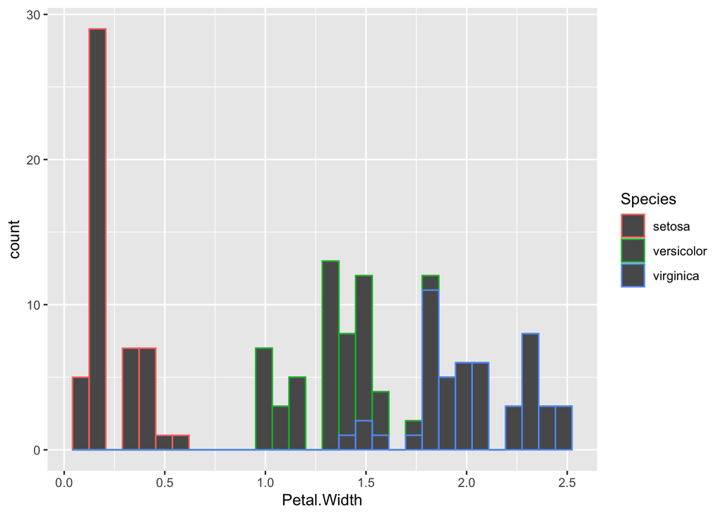

```r
#make a histogram
ggplot(data=iris, aes(x=Petal.Width, color=Species))+
  geom_histogram()
```

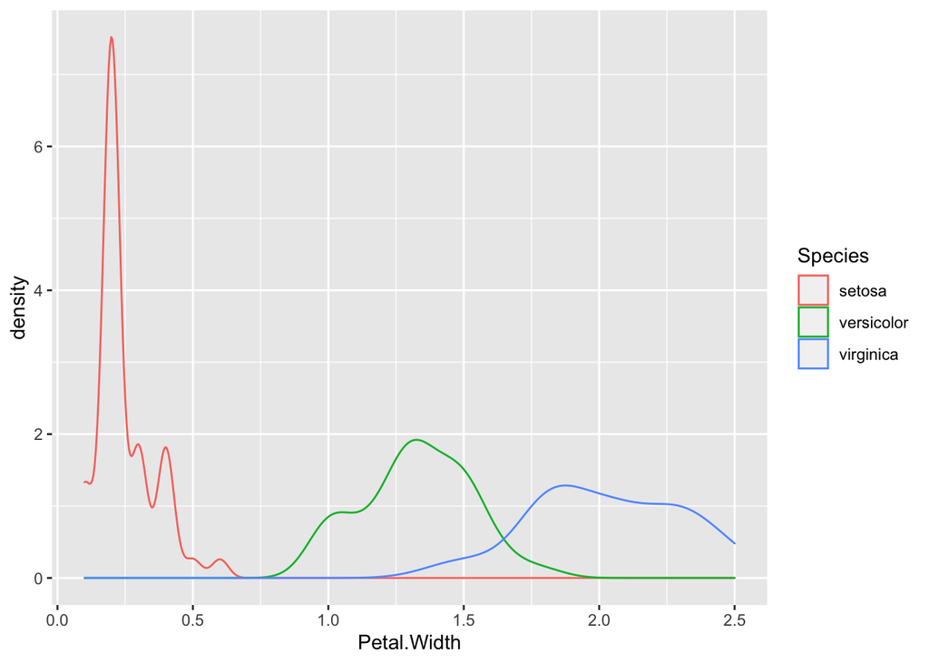

```r
#make a density plot
ggplot(data=iris, aes(x=Petal.Width, color=Species))+
  geom_density()
```

These plots are endlessly modifiable. You can change titles, axes, colors, legends, symbols, etc. etc. etc. You can also combine graphs, and generate image files in different formats. Further description is available through the [tutorial](https://intro2r.com/graphics_r.html) and a really handy source is the ggpplot Cheat Sheet which is available if you scroll down on [this page](https://ggplot2.tidyverse.org/); it’s a neat, handy summary of all the different geoms you can use, and all the syntax and modifications you need.

## Statistics in R

In addition to R’s powerful data manipulation and graphics facilities, R includes a host of procedures which you can use to analyse your data. Many of these procedures are included with the base installation of R, however, even more can be installed with packages available from the CRAN website.

We will look at this very briefly; as always, more detail is available in [the full tutorial](https://intro2r.com/stats_r.html).

Let’s say we want to check whether the iris petal lengths are significantly different between two species. Let’s make two vectors, for the petal length of the setosa and versicolor species. We can test this using a t-test, which we run with the simple function t.test()

```r
setosa_petal_length<-iris[iris$Species=="setosa", "Petal.Length"]
setosa_petal_length
```

```
##  [1] 1.4 1.4 1.3 1.5 1.4 1.7 1.4 1.5 1.4 1.5 1.5 1.6 1.4 1.1 1.2 1.5 1.3 1.4 1.7
## [20] 1.5 1.7 1.5 1.0 1.7 1.9 1.6 1.6 1.5 1.4 1.6 1.6 1.5 1.5 1.4 1.5 1.2 1.3 1.4
## [39] 1.3 1.5 1.3 1.3 1.3 1.6 1.9 1.4 1.6 1.4 1.5 1.4
```

```r
versicolor_petal_length<-iris[iris$Species=="versicolor", "Petal.Length"]
versicolor_petal_length
```

```
##  [1] 4.7 4.5 4.9 4.0 4.6 4.5 4.7 3.3 4.6 3.9 3.5 4.2 4.0 4.7 3.6 4.4 4.5 4.1 4.5
## [20] 3.9 4.8 4.0 4.9 4.7 4.3 4.4 4.8 5.0 4.5 3.5 3.8 3.7 3.9 5.1 4.5 4.5 4.7 4.4
## [39] 4.1 4.0 4.4 4.6 4.0 3.3 4.2 4.2 4.2 4.3 3.0 4.1
```

```r
t.test(versicolor_petal_length, setosa_petal_length)
```

```
##
##  Welch Two Sample t-test
##
## data:  versicolor_petal_length and setosa_petal_length
## t = 39.493, df = 62.14, p-value < 2.2e-16
## alternative hypothesis: true difference in means is not equal to 0
## 95 percent confidence interval:
##  2.656382 2.939618
## sample estimates:
## mean of x mean of y
##     4.260     1.462
```

We can also run statistical tests using formula notation. Let’s look whether petal length is significantly different between all three species.

```r
model<-aov(data=iris, Petal.Length~Species)

summary(model)
```

```
##              Df Sum Sq Mean Sq F value Pr(>F)
## Species       2  437.1  218.55    1180 <2e-16 ***
## Residuals   147   27.2    0.19
## ---
## Signif. codes:  0 '***' 0.001 '**' 0.01 '*' 0.05 '.' 0.1 ' ' 1
```

Is petal length a significant predictor of petal width? We can run a linear model.

```r
lin_model<-lm(data=iris, Petal.Width~Petal.Length)

summary(lin_model)
```

```
##
## Call:
## lm(formula = Petal.Width ~ Petal.Length, data = iris)
##
## Residuals:
##      Min       1Q   Median       3Q      Max
## -0.56515 -0.12358 -0.01898  0.13288  0.64272
##
## Coefficients:
##               Estimate Std. Error t value Pr(>|t|)
## (Intercept)  -0.363076   0.039762  -9.131  4.7e-16 ***
## Petal.Length  0.415755   0.009582  43.387  < 2e-16 ***
## ---
## Signif. codes:  0 '***' 0.001 '**' 0.01 '*' 0.05 '.' 0.1 ' ' 1
##
## Residual standard error: 0.2065 on 148 degrees of freedom
## Multiple R-squared:  0.9271, Adjusted R-squared:  0.9266
## F-statistic:  1882 on 1 and 148 DF,  p-value: < 2.2e-16
```

Understanding and interpreting the statistical tests here is beyond the scope of this tutorial. Learning how to conduct proper statistical analysis of data should be covered in other courses, or in more extensive trainings, books, etc. However, this should give you a glimpse into the types of data analyses you might be able to conduct in R. Much more complicated, scenario-specific tests and analyses are available through packages, which tremendously expand the capability to use R for all sorts of data analysis and intepretation.

## Conclusion

This is the end of our crash-course intro to R!

As we said at the start, the best way to learn R is to use it, and you can always use your existing code (including this tutorial), and endless online resources, in order to write your own code!

Online forums are tremendously helpful (chances are, someone has asked your exact question, and it’s likely someone has written a super helpful answer on a forum like Stack Overflow– there is an amazing user community and lots of people dedicated to helping others use these tools!). And, new AI tools, such as ChatGPT, can be helpful in generating or troubleshooting your code, explaining your code to you, or serving as effective coding “partners”.

Take care in using all of these resources– you want to spend the time to understand what your code is doing, so you can interpret its output and make sure it’s doing what you *think* it’s doing, and what you *want* it to do. But, these tools will set you on your way to becoming a competent programmer, and allow you to answer all sorts of interesting, exciting questions!

Happy coding!